# Raisa

Abanoub Aziz

November 17, 2016

```r
options( java.parameters = "-Xmx4g" )
library(dplyr)
library(knitr)
library(RWeka)
library(tidyr)
library(ggplot2)
library(rjson)
library(caTools)
library(ggmap)
```

```r
train.df <- read.csv('train.csv')
test.df <-  read.csv('test.csv')
metadata.df <- read.csv('metaData_taxistandsID_name_GPSlocation.csv')
```

# Data Exploratory

Number of records in our train dataset

```r
train.df %>% nrow
```

```
## [1] 1710670
```

Number of taxicabs that have been in the train dataset

```r
train.df$TAXI_ID %>% unique %>% length
```

```
## [1] 448
```

Percentage of rows with missing GPS coordinates is very low so we can ignore them.

```r
(train.df %>% filter(MISSING_DATA == 'True') %>% nrow / train.df %>% nrow) * 100
```

```
## [1] 0.0005845663
```

```r
train.df <- train.df %>% filter(MISSING_DATA == 'False')

train.df <- train.df %>% filter(POLYLINE!='[]')
test.df <- test.df %>% filter(POLYLINE!='[]')
```

Number of days with type A (a normal day, workday or weekend)

```r
train.df %>% filter(DAY_TYPE == 'A') %>% nrow
```

```
## [1] 1704759
```

Number of days with type B holiday or any other special day (i.e. extending holidays, floating holidays, etc.)

```r
train.df %>% filter(DAY_TYPE == 'B') %>% nrow
```

```
## [1] 0
```

Number of days with type C (day before a type-B day)

```r
train.df %>% filter(DAY_TYPE == 'C') %>% nrow
```

```
## [1] 0
```

It seems there is error as all the records are DAY_TYPE ‘A’ but this can be handled if we have the official calendar for Portgual. But for we ignore that colmun

```r
train.df <- subset(train.df, select = -DAY_TYPE)
```

Applying stratified sampling to create smaller training dataset

```r
split_rows = sample.split(train.df$CALL_TYPE, SplitRatio=0.2)
train.df <- train.df[split_rows,]
```

# Feature Engineering

Change the unix timestamp to date

```r
train.df <- train.df %>% mutate(date = as.POSIXct(TIMESTAMP, origin="1970-01-01", tz ="WET"))
test.df <- test.df %>% mutate(date = as.POSIXct(TIMESTAMP, origin="1970-01-01", tz ="WET"))
```

- Estimate time for a trip = number of points * 15 seconds.
- Extract the starting point and ending point from the polyline.
- Calculate the distance for the trip using haversineDistance.
- Difference between longitude and lattiudae coordinates between the starting and ending point.
- Calculate average speed for the trip.

```r
train.df$POLYLINE <- as.vector(train.df$POLYLINE)
test.df$POLYLINE <- as.vector(test.df$POLYLINE)

train.df <- train.df %>% rowwise() %>% mutate(points = length(fromJSON(POLYLINE)), start.lon = fromJSON(POLYLINE)[[1]][1], start.lat = fromJSON(POLYLINE)[[1]][2], end.lon = fromJSON(POLYLINE)[[points]][1], end.lat = fromJSON(POLYLINE)[[points]][2], dis = haversineDistance(start.lat, start.lon, end.lat, end.lon), time = points * 15, avg.speed = dis/time, lon.diff = end.lon - start.lon, lat.diff = end.lat - start.lat)

test.df <- test.df %>% rowwise() %>% mutate(points = length(fromJSON(POLYLINE)), start.lon = fromJSON(POLYLINE)[[1]][1], start.lat = fromJSON(POLYLINE)[[1]][2], end.lon = fromJSON(POLYLINE)[[points]][1], end.lat = fromJSON(POLYLINE)[[points]][2], dis = haversineDistance(start.lat, start.lon, end.lat, end.lon), time_so_far = points * 15, avg.speed = dis/time_so_far, lon.diff = end.lon - start.lon, lat.diff = end.lat - start.lat )
```

[figure not shown]

```r
porto_map_roadmap <- get_map(location = "porto", maptype = "roadmap", zoom = 14)
ggmap(porto_map_roadmap, extent = "device") + geom_density2d(data = train.df,
    aes(x = start.lon, y = start.lat), size = 0.3) + stat_density2d(data = train.df,
    aes(x = start.lon, y = start.lat, fill = ..level.., alpha = ..level..), size = 0.01, bins = 16, geom = "polygon") + scale_fill_gradient(low = "green", high = "red") + scale_alpha(range = c(0, 0.3), guide = FALSE)
```

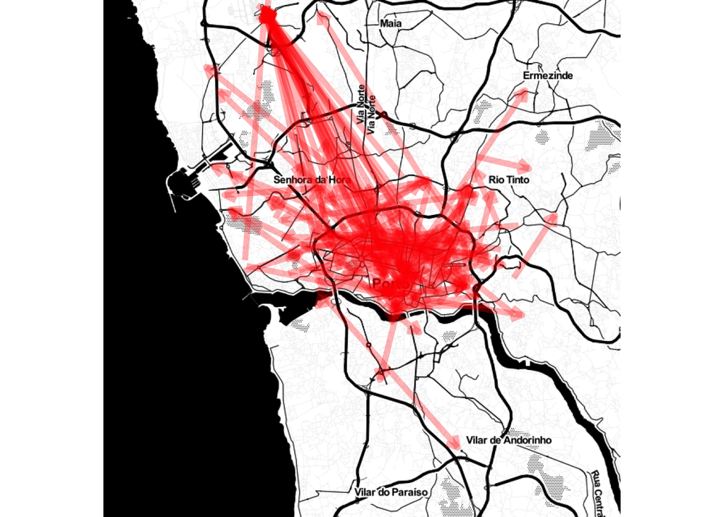

```r
porto_map_toner <- get_map(location = "porto", source = "stamen", maptype = "toner", zoom = 12)
ggmap(porto_map_toner, extent = "device") + geom_segment(aes(x = start.lon, y = start.lat, xend = end.lon, yend = end.lat ), colour = "red", alpha = 0.3, size = 2, data = head(train.df, n= 150), arrow=arrow(length=unit(0.3,"cm")) )
```

# Evaluation models

```r
# Build models
SMOreg <- make_Weka_classifier("weka/classifiers/functions/SMOreg")
MLP <- make_Weka_classifier("weka/classifiers/functions/MultilayerPerceptron")

# Helper function for local CV
evaluateModel <- function(model){
  kFoldModel <- evaluate_Weka_classifier(model, numFolds = 5, seed = 123)
  kFoldModel$details
}

model <- MLP(time ~ start.lon + start.lat + end.lon + end.lat + dis + lat.diff +lon.diff+ CALL_TYPE, data = train.df)
evaluateModel(model)
```

```
##   correlationCoefficient        meanAbsoluteError     rootMeanSquaredError
##                0.3551522              298.7761385              646.3175906
##    relativeAbsoluteError rootRelativeSquaredError
##               85.2433032               95.1274623
```

```r
model <- LinearRegression(time ~ start.lon + start.lat + end.lon + end.lat, data = train.df)
evaluateModel(model)
```

```
##   correlationCoefficient        meanAbsoluteError     rootMeanSquaredError
##               0.05658016             350.44803556             678.34121888
##    relativeAbsoluteError rootRelativeSquaredError
##              99.98572271              99.84082083
```

10-fold Cross Validation from the Azure ML

```r
crossValidation <- read.csv('azureCV.csv')
crossValidation$Model <- gsub("Microsoft.Analytics.MachineLearning.Local.BatchLinearRegressor", "Decision Trees", crossValidation$Model)
crossValidation <- read.csv('azureCV.csv')
crossValidation$Model <- gsub("Microsoft.Analytics.Modules.Gemini.Dll.GeminiDecisionForestRegressor", "Decision Trees", crossValidation$Model)
crossValidation$Model <- gsub("Microsoft.Analytics.MachineLearning.Local.BayesianLinearRegressor", "BayesianLinearRegressor", crossValidation$Model)
crossValidation$Model <- gsub("Microsoft.Analytics.MachineLearning.Local.BatchLinearRegressor", "LinearRegressor", crossValidation$Model)

summary <- crossValidation %>% group_by(Model) %>% summarise(Mean.Absolute.Error = mean(Mean.Absolute.Error), Root.Mean.Squared.Error = mean(Root.Mean.Squared.Error),Relative.Absolute.Error = mean(Relative.Absolute.Error), Relative.Squared.Error = mean(Relative.Squared.Error))
summary %>% kable
```

| Model | Mean.Absolute.Error | Root.Mean.Squared.Error | Relative.Absolute.Error | Relative.Squared.Error |
| --- | --- | --- | --- | --- |
| BayesianLinearRegressor | 265.6784 | 580.7460 | 0.7611117 | 0.7821178 |
| Decision Trees | 249.4184 | 572.5041 | 0.7147723 | 0.7624440 |
| LinearRegressor | 265.6855 | 580.7466 | 0.7611328 | 0.7821186 |
| Regression Neural Network | 321.0144 | 635.3541 | 0.9194119 | 0.9411685 |

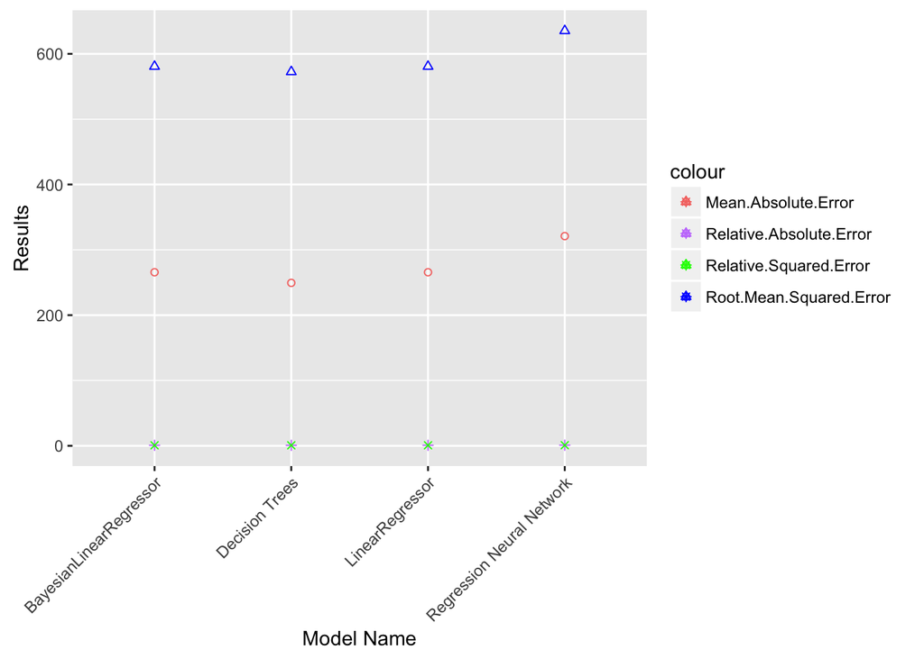

```r
ggplot(summary, aes(Model)) +
  geom_point(aes(y = Mean.Absolute.Error, colour ='Mean.Absolute.Error'), size=1.5, group = 1, shape=1) + geom_point(aes(y = Root.Mean.Squared.Error, colour = 'Root.Mean.Squared.Error'), size= 1.5, group = 1, shape=2)+ geom_point(aes(y = Relative.Absolute.Error, colour = 'Relative.Absolute.Error'), size= 1.5, group = 1, shape=3)+ geom_point(aes(y = Relative.Squared.Error, colour = 'Relative.Squared.Error'), size= 1.5, group = 1, shape=4)+
  xlab("Model Name")+ylab("Results")  +
  scale_colour_manual(values=c("#F57670","#C680FC","GREEN","BLUE"))+
  theme(axis.text.x = element_text(angle = 45, hjust = 1))
```

```r
myTarget = predict(model, newdata = test.df)
myResult <- data.frame(TRIP_ID=test.df$TRIP_ID, TRAVEL_TIME=myTarget, time = test.df$time_so_far)
myResult <- myResult %>% rowwise() %>% mutate(TRAVEL_TIME = max(TRAVEL_TIME,time))
myResult$time <- NULL
#write.table(myResult, file="Submissions/result35.csv", sep =",", row.names= FALSE)
```